# Sampling and iteration in Tidyverse

Uzezi Okinedo

9/18/2020

```r
# Libraries for this assignment

library(dplyr)
library(purrr)
library(kableExtra)
```

# 1. Some data with Flippers

## 1a. Load the library palmerpenguins after installing it

```r
library(palmerpenguins)            # Load library palmerpenguins
```

## 1b. Show the head of the dataset penguins

```r
penguins %>%                       # penguins dataset
  head() %>%                       # head of penguins dataset
  kbl() %>%
  kable_styling()                  # Using KableExtra table formatting
```

| species | island | bill_length_mm | bill_depth_mm | flipper_length_mm | body_mass_g | sex | year |
| --- | --- | --- | --- | --- | --- | --- | --- |
| Adelie | Torgersen | 39.1 | 18.7 | 181 | 3750 | male | 2007 |
| Adelie | Torgersen | 39.5 | 17.4 | 186 | 3800 | female | 2007 |
| Adelie | Torgersen | 40.3 | 18.0 | 195 | 3250 | female | 2007 |
| Adelie | Torgersen | NA | NA | NA | NA | NA | 2007 |
| Adelie | Torgersen | 36.7 | 19.3 | 193 | 3450 | female | 2007 |
| Adelie | Torgersen | 39.3 | 20.6 | 190 | 3650 | male | 2007 |

## 1c. What do you learn by using str() and summary() on penguins()

```r
penguins %>%
  summary()                      # Summary of penguins dataset
```

```
##       species          island    bill_length_mm  bill_depth_mm
##  Adelie   :152   Biscoe   :168   Min.   :32.10   Min.   :13.10
##  Chinstrap: 68   Dream    :124   1st Qu.:39.23   1st Qu.:15.60
##  Gentoo   :124   Torgersen: 52   Median :44.45   Median :17.30
##                                  Mean   :43.92   Mean   :17.15
##                                  3rd Qu.:48.50   3rd Qu.:18.70
##                                  Max.   :59.60   Max.   :21.50
##                                  NA's   :2       NA's   :2
##  flipper_length_mm  body_mass_g       sex           year
##  Min.   :172.0     Min.   :2700   female:165   Min.   :2007
##  1st Qu.:190.0     1st Qu.:3550   male  :168   1st Qu.:2007
##  Median :197.0     Median :4050   NA's  : 11   Median :2008
##  Mean   :200.9     Mean   :4202                Mean   :2008
##  3rd Qu.:213.0     3rd Qu.:4750                3rd Qu.:2009
##  Max.   :231.0     Max.   :6300                Max.   :2009
##  NA's   :2         NA's   :2
```

What the summary shows;

1. It shows the descriptive statistics of the dataset. This includes the min, max, mean, median, and quartiles of each column.
2. It shows the names of each column in the dataset
3. It also identifies columns with missing values(NA)

```r
penguins %>%
  str()                           # structure of penguins dataset
```

```
## tibble [344 x 8] (S3: tbl_df/tbl/data.frame)
##  $ species          : Factor w/ 3 levels "Adelie","Chinstrap",..: 1 1 1 1 1 1 1 1 1 1 ...
##  $ island           : Factor w/ 3 levels "Biscoe","Dream",..: 3 3 3 3 3 3 3 3 3 3 ...
##  $ bill_length_mm   : num [1:344] 39.1 39.5 40.3 NA 36.7 39.3 38.9 39.2 34.1 42 ...
##  $ bill_depth_mm    : num [1:344] 18.7 17.4 18 NA 19.3 20.6 17.8 19.6 18.1 20.2 ...
##  $ flipper_length_mm: int [1:344] 181 186 195 NA 193 190 181 195 193 190 ...
##  $ body_mass_g      : int [1:344] 3750 3800 3250 NA 3450 3650 3625 4675 3475 4250 ...
##  $ sex              : Factor w/ 2 levels "female","male": 2 1 1 NA 1 2 1 2 NA NA ...
##  $ year             : int [1:344] 2007 2007 2007 2007 2007 2007 2007 2007 2007 2007 ...
```

What the structure explains;

1. It shows the dimensions of the dataset = 344 x 8
2. It shows the class of each column. For example; ‘species’, ‘island’ and ‘sex’ are factors.

## 1d. What are the quantiles of bill depth across the whole data set? What do those quantiles mean?

```r
penguins %>%                      # load penguins data
  select(bill_depth_mm) %>%       # select the bill depth column using the select() from dplyr.
  quantile(na.rm = TRUE)          # calculate the quantiles using the quantile()
```

```
##   0%  25%  50%  75% 100%
## 13.1 15.6 17.3 18.7 21.5
```

# 2. DIPLYR

## 2a. If I have a vector, c(1,4,7,NA,9), what is its mean? Note, the NA is going to cause a problem. Look at ?mean to learn how to solve it.

```r
c(1,4,7,NA,9) %>%                 # create a vector
mean(na.rm = TRUE)                # calculate the mean using the mean() and setting na.rm = TRUE to remove missing values
```

```
## [1] 5.25
```

## 2b. What is the mean, sd, and median of body mass across the data set? Note, these NAs are going to cause some problems, so you might need to look at the documentation for the relevant functions.

```r
penguins %>%                                         # load penguin data
  summarise(
    mean_body_mass = mean(body_mass_g, na.rm = TRUE),# Calculate the mean, sd and median of the body mass and summarize results into a data frame
    sd_body_mass = sd(body_mass_g, na.rm = TRUE),
    med_body_mass = median(body_mass_g, na.rm = TRUE)) %>%
  kbl() %>%
  kable_styling()                  # Using KableExtra table formatting
```

| mean_body_mass | sd_body_mass | med_body_mass |
| --- | --- | --- |
| 4201.754 | 801.9545 | 4050 |

## 2c. Repeat 2b, but, show us how these quantities differ by species

```r
penguins %>%
  group_by(species) %>% #group all species in the data using group_by function
  summarise(
    mean_body_mass = mean(body_mass_g, na.rm = TRUE),  # repeat 2b above
    sd_body_mass = sd(body_mass_g, na.rm = TRUE),
    med_body_mass = median(body_mass_g, na.rm = TRUE)) %>%
  kbl() %>%
  kable_styling()                  # Using KableExtra table formatting
```

| species | mean_body_mass | sd_body_mass | med_body_mass |
| --- | --- | --- | --- |
| Adelie | 3700.662 | 458.5661 | 3700 |
| Chinstrap | 3733.088 | 384.3351 | 3700 |
| Gentoo | 5076.016 | 504.1162 | 5000 |

## 2d. Repeat 2c, but just for Biscoe island. What is different in the results?

```r
penguins %>%
  filter(island == "Biscoe") %>% # filtered out Biscoe island using the filter()
  group_by(species, island) %>%  # Grouped species and island from dataset
  summarise(
    mean_body_mass = mean(body_mass_g, na.rm = TRUE),  # same as 2c above
    sd_body_mass = sd(body_mass_g, na.rm = TRUE),
    med_body_mass = median(body_mass_g, na.rm = TRUE)) %>%
kbl() %>%
  kable_styling()                  # Using KableExtra table formatting
```

| species | island | mean_body_mass | sd_body_mass | med_body_mass |
| --- | --- | --- | --- | --- |
| Adelie | Biscoe | 3709.659 | 487.7337 | 3750 |
| Gentoo | Biscoe | 5076.016 | 504.1162 | 5000 |

The ‘Chinstrap’ specie is not included in the summarized dataframe. It can be inferred that the Chinstrap species is not found in Biscoe island.

## 2e. Make a species-island column in penguins using paste(). This is an awesome function that takes multiple strings, and slams them together using the argument sep = to define how the string should be combined.

```r
penguins %>%    # pipe penguin data
group_by(species, island) %>% # group the species and island column together
mutate('species-island' = paste(as.character(species), as.character(island), sep = "_")) %>%   # create a new dataframe with 'species' island column using mutate() and paste(sep = "_")
kbl() %>%
kable_styling() # Using KableExtra table formatting
```

| species | island | bill_length_mm | bill_depth_mm | flipper_length_mm | body_mass_g | sex | year | species-island |
| --- | --- | --- | --- | --- | --- | --- | --- | --- |
| Adelie | Torgersen | 39.1 | 18.7 | 181 | 3750 | male | 2007 | Adelie_Torgersen |
| Adelie | Torgersen | 39.5 | 17.4 | 186 | 3800 | female | 2007 | Adelie_Torgersen |
| Adelie | Torgersen | 40.3 | 18.0 | 195 | 3250 | female | 2007 | Adelie_Torgersen |
| Adelie | Torgersen | NA | NA | NA | NA | NA | 2007 | Adelie_Torgersen |
| Adelie | Torgersen | 36.7 | 19.3 | 193 | 3450 | female | 2007 | Adelie_Torgersen |
| Adelie | Torgersen | 39.3 | 20.6 | 190 | 3650 | male | 2007 | Adelie_Torgersen |
| Adelie | Torgersen | 38.9 | 17.8 | 181 | 3625 | female | 2007 | Adelie_Torgersen |
| Adelie | Torgersen | 39.2 | 19.6 | 195 | 4675 | male | 2007 | Adelie_Torgersen |
| Adelie | Torgersen | 34.1 | 18.1 | 193 | 3475 | NA | 2007 | Adelie_Torgersen |
| Adelie | Torgersen | 42.0 | 20.2 | 190 | 4250 | NA | 2007 | Adelie_Torgersen |
| Adelie | Torgersen | 37.8 | 17.1 | 186 | 3300 | NA | 2007 | Adelie_Torgersen |
| Adelie | Torgersen | 37.8 | 17.3 | 180 | 3700 | NA | 2007 | Adelie_Torgersen |
| Adelie | Torgersen | 41.1 | 17.6 | 182 | 3200 | female | 2007 | Adelie_Torgersen |
| Adelie | Torgersen | 38.6 | 21.2 | 191 | 3800 | male | 2007 | Adelie_Torgersen |
| Adelie | Torgersen | 34.6 | 21.1 | 198 | 4400 | male | 2007 | Adelie_Torgersen |
| Adelie | Torgersen | 36.6 | 17.8 | 185 | 3700 | female | 2007 | Adelie_Torgersen |
| Adelie | Torgersen | 38.7 | 19.0 | 195 | 3450 | female | 2007 | Adelie_Torgersen |
| Adelie | Torgersen | 42.5 | 20.7 | 197 | 4500 | male | 2007 | Adelie_Torgersen |
| Adelie | Torgersen | 34.4 | 18.4 | 184 | 3325 | female | 2007 | Adelie_Torgersen |
| Adelie | Torgersen | 46.0 | 21.5 | 194 | 4200 | male | 2007 | Adelie_Torgersen |
| Adelie | Biscoe | 37.8 | 18.3 | 174 | 3400 | female | 2007 | Adelie_Biscoe |
| Adelie | Biscoe | 37.7 | 18.7 | 180 | 3600 | male | 2007 | Adelie_Biscoe |
| Adelie | Biscoe | 35.9 | 19.2 | 189 | 3800 | female | 2007 | Adelie_Biscoe |
| Adelie | Biscoe | 38.2 | 18.1 | 185 | 3950 | male | 2007 | Adelie_Biscoe |
| Adelie | Biscoe | 38.8 | 17.2 | 180 | 3800 | male | 2007 | Adelie_Biscoe |
| Adelie | Biscoe | 35.3 | 18.9 | 187 | 3800 | female | 2007 | Adelie_Biscoe |
| Adelie | Biscoe | 40.6 | 18.6 | 183 | 3550 | male | 2007 | Adelie_Biscoe |
| Adelie | Biscoe | 40.5 | 17.9 | 187 | 3200 | female | 2007 | Adelie_Biscoe |
| Adelie | Biscoe | 37.9 | 18.6 | 172 | 3150 | female | 2007 | Adelie_Biscoe |
| Adelie | Biscoe | 40.5 | 18.9 | 180 | 3950 | male | 2007 | Adelie_Biscoe |

[output cut: 314 more lines]

# 3. PLOTTING

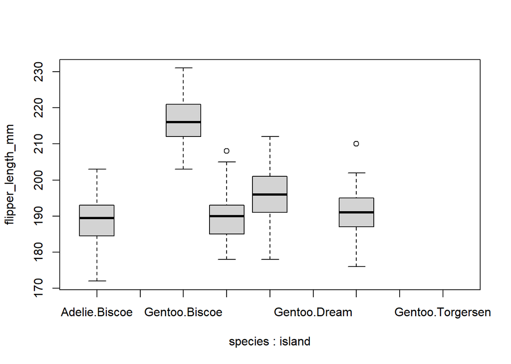

```r
penguins %>%    # pipe penguin data
  group_by(species, island) %>%
  mutate('species-island' = paste(as.character(species), as.character(island), sep = "\n")) %>%  # create a new dataframe with 'species' island column using mutate() and paste(sep = "\n")
  summarise(flipper_length_mm, 'species-island') %>%



  boxplot(flipper_length_mm ~ species-island, data = .) # make a boxplot
```

# 3b. Show the relationship between average flipper length and average body mass by species and island. What do you see?

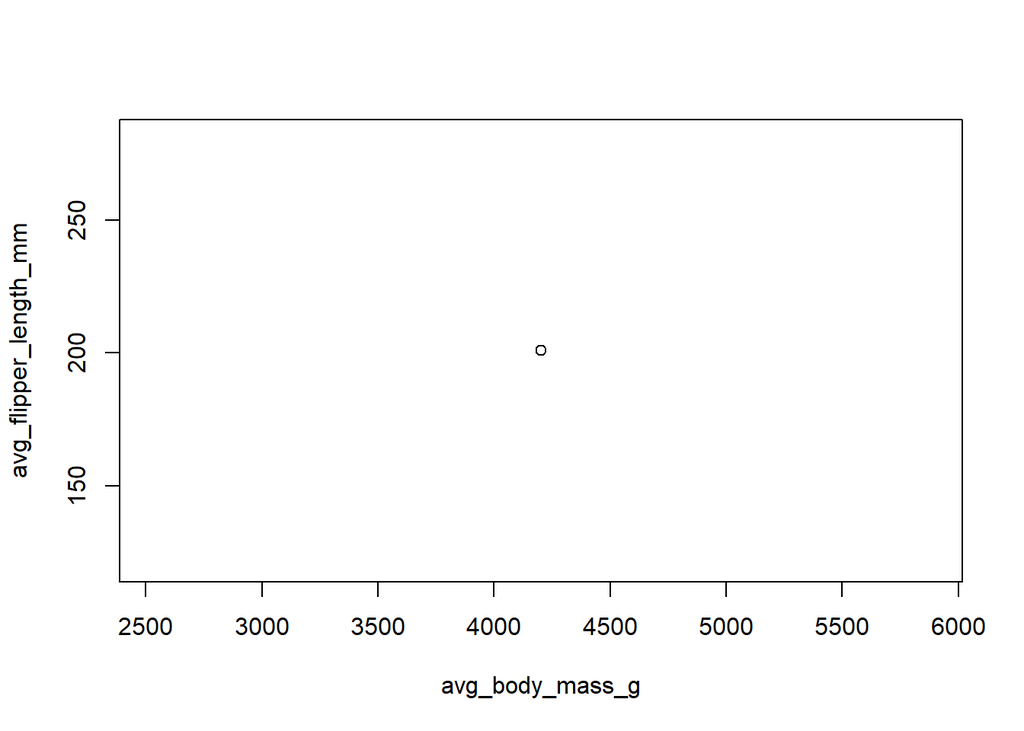

```r
penguins %>%       # pipe penguin data
  mutate(`species-island` = paste("species", "island", sep = "\n")) %>%                  # add a new species-island column using mutate() and paste(sep = "\n")
  summarise(avg_flipper_length_mm = mean(flipper_length_mm, na.rm = TRUE), avg_body_mass_g = mean(body_mass_g, na.rm = TRUE)) %>% # create a data frame that summarizes rouped elements

  plot(avg_flipper_length_mm ~ avg_body_mass_g, data = .) # plot average flipper length against average body mass
```

# 3c. Interesting. What if you had made the same plot with the whole dataset? What do you see? Is there anything that could clarify the result any more? Think about it - lots of possible right answers here.

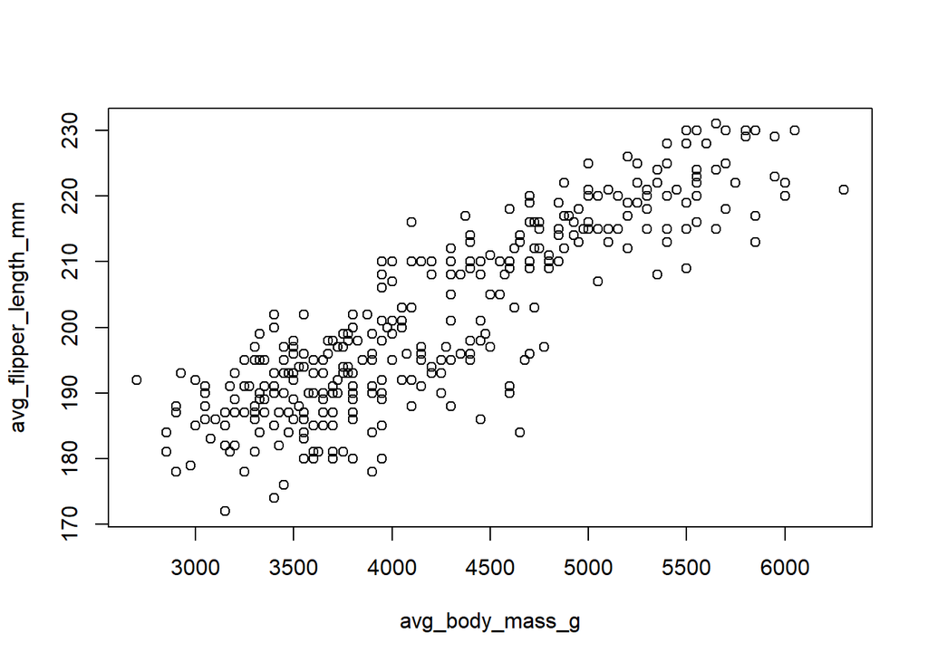

```r
penguins %>%        # pipe penguin data
  group_by(flipper_length_mm, body_mass_g) %>%
 summarize(avg_flipper_length_mm = mean(flipper_length_mm, na.rm = TRUE), avg_body_mass_g = mean(body_mass_g, na.rm = TRUE)) %>% # create a new column of average flipper length and average body mass in the penguins data set using mutate()

  plot(avg_flipper_length_mm ~ avg_body_mass_g, data = .) # plot average flipper length against average body mass using the whole dataset
```

## 4. Simulation

# **4a.Grab the values for bill_length_mm for Gentoo penguins in Biscoe Island and put it into an object. Note, the dplyr function pull() is kinda cool, as if you apply it to a data frame, it will pull out a vector from a column of interest.**

```r
bill_gent_bis <- penguins %>%
  group_by(species, island) %>% # create a new dataframe with values for bill length for Gentoo species in Biscoe island
  filter(species == "Gentoo" | island == "Biscoe") %>%  # Filter Gentoo species and Biscoe island
  pull(bill_length_mm) # Use pull() to select bill length

bill_gent_bis
```

```
##   [1] 37.8 37.7 35.9 38.2 38.8 35.3 40.6 40.5 37.9 40.5 39.6 40.1 35.0 42.0 34.5
##  [16] 41.4 39.0 40.6 36.5 37.6 35.7 41.3 37.6 41.1 36.4 41.6 35.5 41.1 35.0 41.0
##  [31] 37.7 37.8 37.9 39.7 38.6 38.2 38.1 43.2 38.1 45.6 39.7 42.2 39.6 42.7 46.1
##  [46] 50.0 48.7 50.0 47.6 46.5 45.4 46.7 43.3 46.8 40.9 49.0 45.5 48.4 45.8 49.3
##  [61] 42.0 49.2 46.2 48.7 50.2 45.1 46.5 46.3 42.9 46.1 44.5 47.8 48.2 50.0 47.3
##  [76] 42.8 45.1 59.6 49.1 48.4 42.6 44.4 44.0 48.7 42.7 49.6 45.3 49.6 50.5 43.6
##  [91] 45.5 50.5 44.9 45.2 46.6 48.5 45.1 50.1 46.5 45.0 43.8 45.5 43.2 50.4 45.3
## [106] 46.2 45.7 54.3 45.8 49.8 46.2 49.5 43.5 50.7 47.7 46.4 48.2 46.5 46.4 48.6
## [121] 47.5 51.1 45.2 45.2 49.1 52.5 47.4 50.0 44.9 50.8 43.4 51.3 47.5 52.1 47.5
## [136] 52.2 45.5 49.5 44.5 50.8 49.4 46.9 48.4 51.1 48.5 55.9 47.2 49.1 47.3 46.8
## [151] 41.7 53.4 43.3 48.1 50.5 49.8 43.5 51.5 46.2 55.1 44.5 48.8 47.2   NA 46.8
## [166] 50.4 45.2 49.9
```

# 4b.Use replicate() to calculate the standard error of the mean 10 times. Use a formula! Don’t forget that NA values shouldn’t be included!

```r
as.data.frame(bill_gent_bis) %>%  # covert bill_gent_bis containing bill length of Gentoo species in Biscoe island
  summarise(sd = sd(bill_gent_bis, na.rm = TRUE), n = n(),  se = replicate(n =10, sd/sqrt(n))) %>%  # calculate the standard deviations, replicate standard error 10x and summarize
  na.omit() %>%  # omit missing values
kbl() %>%
  kable_styling()                  # Using KableExtra table formatting
```

| sd | n | se |
| --- | --- | --- |
| 4.772731 | 168 | 0.3682242 |
| 4.772731 | 168 | 0.3682242 |
| 4.772731 | 168 | 0.3682242 |
| 4.772731 | 168 | 0.3682242 |
| 4.772731 | 168 | 0.3682242 |
| 4.772731 | 168 | 0.3682242 |
| 4.772731 | 168 | 0.3682242 |
| 4.772731 | 168 | 0.3682242 |
| 4.772731 | 168 | 0.3682242 |
| 4.772731 | 168 | 0.3682242 |

# 4c.Use map_df() to create a data frame with the mean and sd of different sample sizes using the first 5 through 100 values (so, n = 5:100 - smallest sample size will have the values 1-5). Make sure the sample size is included in the final data frame.

```r
library(purrr)

my_vec <- 1:100      # create a vector containing number 1 through 100

my_vec_data <- map_df(5:100, ~data.frame(m = mean(my_vec[1:.x]),
                         sd = sd(my_vec[1:.x])),
       .id = "sample_size")    # use map_df to create a data frame from the created vector.


my_vec_data      # view new data frame
```

```
##    sample_size    m        sd
## 1            1  3.0  1.581139
## 2            2  3.5  1.870829
## 3            3  4.0  2.160247
## 4            4  4.5  2.449490
## 5            5  5.0  2.738613
## 6            6  5.5  3.027650
## 7            7  6.0  3.316625
## 8            8  6.5  3.605551
## 9            9  7.0  3.894440
## 10          10  7.5  4.183300
## 11          11  8.0  4.472136
## 12          12  8.5  4.760952
## 13          13  9.0  5.049752
## 14          14  9.5  5.338539
```

[output cut: 82 more lines]

# 4d. Plot the relationship between sample size and SD and sample size versus SE of the mean. What difference do you see and why? Note, you’ll need to create a column for SE here!

# +2 EC for using par() to make a two-panel plot. Don’t forget to reset back to a single plot per panel after making a two-panel plot. Otherwise things get weird.

```r
my_vec_data_02 <- my_vec_data %>%         # pipe data frame containing mean and SD of samples
  group_by(sample_size, sd) %>%    # group sample size and SD
  summarise(sample_size, sd, n = n(), se = sd/sqrt(n))    # calculate standard error and summarize sample_size, standard deviation and Standard error into one data frame
my_vec_data_02     # summarized data showing se column
```

```
## # A tibble: 96 x 4
## # Groups:   sample_size [96]
##    sample_size    sd     n    se
##    <chr>       <dbl> <int> <dbl>
##  1 1            1.58     1  1.58
##  2 10           4.18     1  4.18
##  3 11           4.47     1  4.47
##  4 12           4.76     1  4.76
##  5 13           5.05     1  5.05
##  6 14           5.34     1  5.34
##  7 15           5.63     1  5.63
##  8 16           5.92     1  5.92
##  9 17           6.20     1  6.20
## 10 18           6.49     1  6.49
## # ... with 86 more rows
```

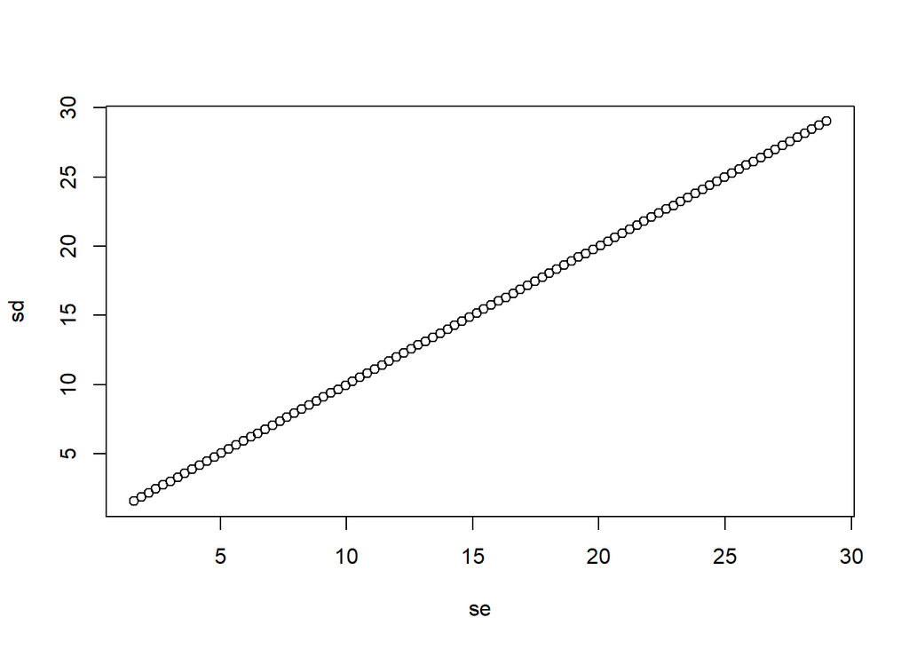

```r
  plot(sd ~ se, data = my_vec_data_02)     # plot standard deviation against standard error
```

There’s no difference between the SD and SE. That is; SD = SE

# +2 using par() for multiple plots

I plotted the standard Errors using plot() and hist() side by side

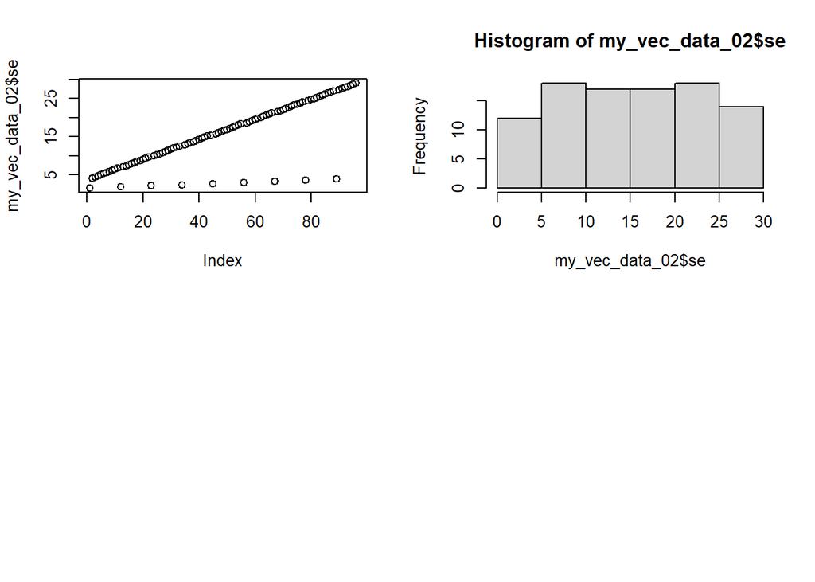

```r
par(mfrow = c(2, 2))     # setting the two panel plot
plot(my_vec_data_02$se)  # plot se from my_vec_data_02
hist(my_vec_data_02$se)  # make a histogram to show the distrubution of se from my_vec data
par(mfrow = c(1, 1))     # undo two-panel plot
```

[GitHub Extra Credit](https://github.com/Uzezi93/BIOL-607-Homework-Fall-2020-/commit/745194df46ba900beb74204c12cfed729bafbe79)